# Effect of tornadoes on water quality parameters

Peter Menzies

10/18/2021

## Introduction

This project seeks to answer the environmental question: What are the effects of tornadoes on key water quality parameters? The following code loads in relevant data sets on tornadoes and water through APIs and presents preliminary analysis. The project’s data management plan, data log, and code to query and analyze the API are included in the GitHub repository. These data sets and accompanying metadata are preserved on KNB as data packages.

## 1. US water quality data

This study site and associated information was found using the USGS National Water Dashboard. Site information can be found at https://waterdata.usgs.gov/nwis/uv?site_no=07263296. The parameter codes were pulled from https://help.waterdata.usgs.gov/parameter_cd?group_cd=%25. Data from the NWIS web service is derived from https://waterservices.usgs.gov/.

### Assigning API query components

```r
## Maumelle River near Wye, AR - flows through Oklahoma and drains to Mississippi
## Water data back to 1989, if available.
siteNumber <- c("07263296")

## Parameter codes for temp, discharge, turbidity, dissolved o2, and suspended sediment conc., respectively
parameterCd <- c("00010", "00060", "63680", "00300", "99409")

## Temporal range of our current study
startDate <- "1989-01-01"
endDate <- "2021-10-01"
```

### Import data from NWIS web service

```r
# Imports data using query components from above and changes column names to readable text
water <- readNWISdv(siteNumber, parameterCd, startDate, endDate) %>%
  rename(water_temp_c = X_00010_00003,
         discharge_cfs = X_00060_00003,
         turbidity_fnu = X_63680_00003,
         diss_o2_mgl = X_00300_00003) %>%
  select(Date, water_temp_c, discharge_cfs, diss_o2_mgl, turbidity_fnu)
```

```r
# Export water data
write.csv(water, "~/Downloads/maumelle_water_2007-2021.csv")
```

### Import various embedded metadata

Source for all dataRetrieval embedded metadata functions: https://cran.r-project.org/web/packages/dataRetrieval/vignettes/dataRetrieval.html#embedded-metadata

```r
# embedded metadata
print(paste0("URL of water data query: ", attr(water, "url")))
```

```
## [1] "URL of water data query: https://waterservices.usgs.gov/nwis/dv/?site=07263296&format=waterml,1.1&ParameterCd=00010,00060,63680,00300,99409&StatCd=00003&startDT=1989-01-01&endDT=2021-10-01"
```

```r
print(paste0("Time API accessed: ", attr(water, "queryTime")))
```

```
## [1] "Time API accessed: 2021-10-26 21:51:26"
```

## 2. US tornado data

Tornado data is retrieved from NOAA’s National Weather Service found at https://www.spc.noaa.gov/wcm/#data.

### Read in tornado data

```r
# Create data frame
tornadoes <- rnoaa::tornadoes()
```

### Exploring spatial distribution of tornadoes magnitude 3 and above near stream site

[figure not shown]

```r
# Creating location of monitor object
monitor = attr(water, "siteInfo")

# Filtering tornadoes based on magnitude, location, and time of ocurrance
big_T = tornadoes %>%
  st_as_sf() %>%
  filter(mag > 2,
         slat < 36,
         slon > -95,
         yr >=2007,
         yr <= 2019,
         st %in% c("AR", "KS", "NE", "OK")) %>%
  mutate(date = as.Date(date))

# Plotting tornado locations
T_plot = ggplot(data = big_T, aes(x = slon, y = slat)) +
  geom_point(aes(color = yr))

# Adding location of Maumelle stream site to plot
T_plot +
  geom_point(data = monitor, mapping = aes(x = dec_lon_va, y = dec_lat_va), color = "red") +
  theme_classic() +
  labs(x = "Starting Latitute (WGS84)",
       y = "Starting Longitute (WGS84)",
       title = "Major Tornado Occurrences Near Maumelle, AR Water Gauge, 2007-2019")
```

### Comparing stream measurement time-series with close-proximity tornado occurance

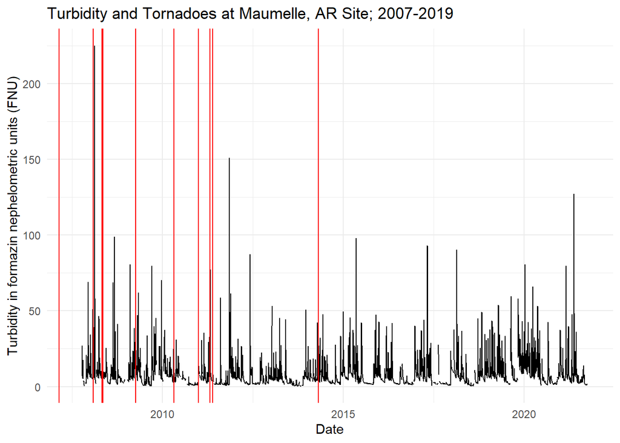

```r
mau_water_turb <- ggplot(water, aes(x = Date, y = turbidity_fnu)) +
  geom_line() +
  geom_vline(data = big_T, aes(xintercept = big_T$date), color = 'red') +
  theme_minimal() +
  labs(title = "Turbidity and Tornadoes at Maumelle, AR Site; 2007-2019",
       y = "Turbidity in formazin nephelometric units (FNU)")

mau_water_dis <- ggplot(water, aes(x = Date, y = discharge_cfs)) +
  geom_line() +
  geom_vline(data = big_T, aes(xintercept = big_T$date), color = 'red') +
  theme_minimal() +
  labs(title = "Discharge and Tornadoes at Maumelle, AR Site; 2007-2019",
       y = "Stream discharge (ft³/s)")

mau_water_o2 <- ggplot(water, aes(x = Date, y = diss_o2_mgl)) +
  geom_line() +
  geom_vline(data = big_T, aes(xintercept = big_T$date), color = 'red') +
  theme_minimal() +
  labs(title = "Dissolved Oxygen and Tornadoes at Maumelle, AR Site",
       y = "Dissolved oxygen (mg/L)")

mau_water_temp <- ggplot(water, aes(x = Date, y = water_temp_c)) +
  geom_line() +
  geom_vline(data = big_T, aes(xintercept = big_T$date), color = 'red') +
  theme_minimal() +
  labs(title = "Water Temperature and Tornadoes at Maumelle, AR Site",
       y = "Water temperature (°C)")

mau_water_turb
```

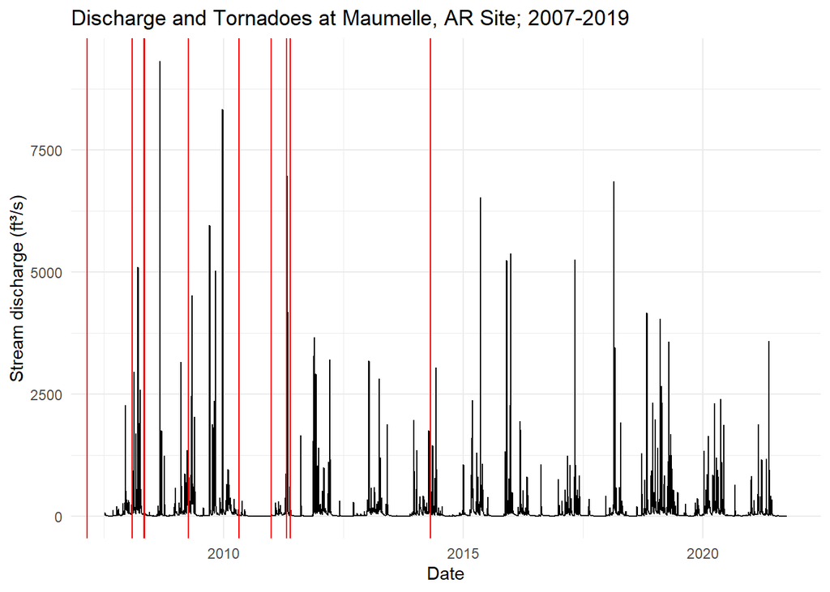

```r
mau_water_dis
```

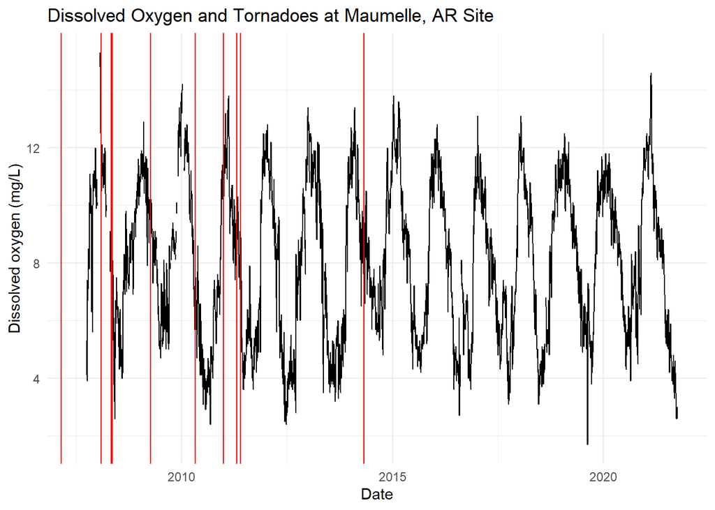

```r
mau_water_o2
```

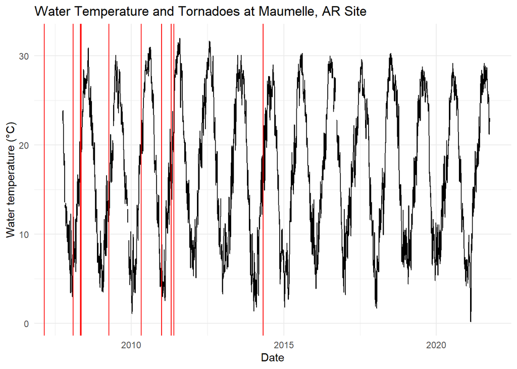

```r
mau_water_temp
```

## 3. Future Directions

The most logical next step identified by our team in order to gain better understanding of the effects of tornadoes on stream water quality beyond the data presented here would be to expand our analysis to a greater number of stream monitoring sites. This is an obvious step to expand the available data, but there are many smaller processes involved in integrating future stream data into our analysis here.

The addition of more monitoring sites will involve (potentially substantial) data integration and merging. Simplification of the merging process is yet another reason to restrict expansion to those sites that track the same metrics already investigated here.

Finally, our current project is limited to one site, and therefore much of our analysis is based off of interpretation of data visualizations such as the graphs above. The integration of more datasets from other monitoring stations would provide a better basis for more robust statistical analysis that may be able to detect a more nuanced interaction between tornadoes and stream chemistry than is presented here.

Additional statistical analysis beyond the visualizations above could be performed to more accurately assess the relationship between tornadoes and water quality data. An example of the potential merging of these datasets for the same site is provided below.

```r
# Filter tornadoes
tornadoes_subset <- tornadoes %>%
  st_as_sf() %>%
  filter(yr >= 2007,
         yr <= 2019,
         mag > 2) %>%
  st_transform(crs = 32616) # WGS 84 / UTM zone 16N

# Create spatial data frame of site location
site_location <- st_sfc(st_point(c(monitor$dec_lon_va, monitor$dec_lat_va)), crs = 4326) %>%
  st_transform(crs = 32616)

# Buffer site
site_buffer <- st_buffer(site_location, dist = 100000)

# Crop tornadoes to site buffer
tornadoes_cropped <- tornadoes_subset[site_buffer, op = st_intersects]

# Pull out dates of tornadoes near site
tornado_dates <- select(.data = tornadoes_cropped, date, mag) %>%
  st_drop_geometry() %>%
  mutate(date = as.Date(date))

# Add +/- 10 days to either side of date
date_vector <- vector()
for (i in seq_along(tornado_dates$date)) {
  for (j in seq(-10, 10, 1)) {
    date_vector <- c(date_vector, tornado_dates$date[i] + j)
  }
}

# Change date vector back to date class
date_vector <- as.Date(date_vector, origin = "1970-01-01")

# Use date vector to filter water data
water_tornado_effects <- water %>%
  filter(Date %in% date_vector)
```

### Potential Visualizations

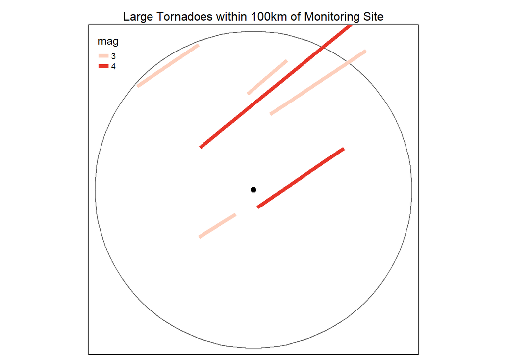

```r
# Show site location, different spatial join method (buffer), and resulting tornadoes
path_viz =  tm_shape(site_buffer) +
  tm_polygons(col = "white") +
tm_shape(site_location) +
  tm_dots(size = 0.25) +
tm_shape(tornadoes_cropped) +
  tm_lines(col = "mag",
           palette = "Reds",
           lwd = 5) +
  tm_layout(main.title = "Large Tornadoes within 100km of Monitoring Site",
            main.title.position = "center",
            main.title.size = 1)

tmap_save(tm = path_viz, filename = "tornado_path.jpg")

path_viz
```

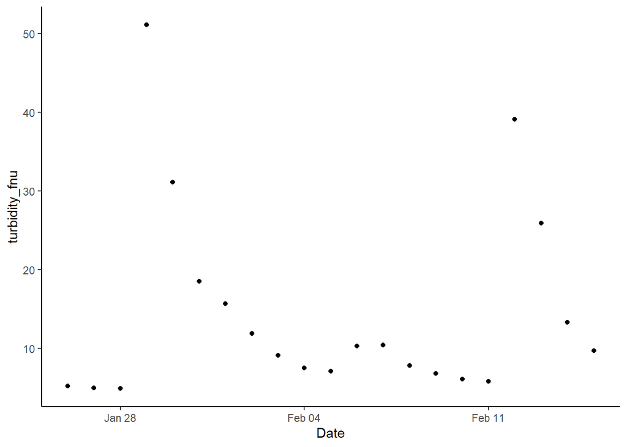

```r
# Show water quality data for +/- 10 days of a single tornado
ggplot(data = water_tornado_effects[1:21, ], aes(x = Date, y = turbidity_fnu)) +
  geom_vline(xintercept = median(water_tornado_effects$Date), color = "red") +
  geom_point() +
  theme_classic()
```

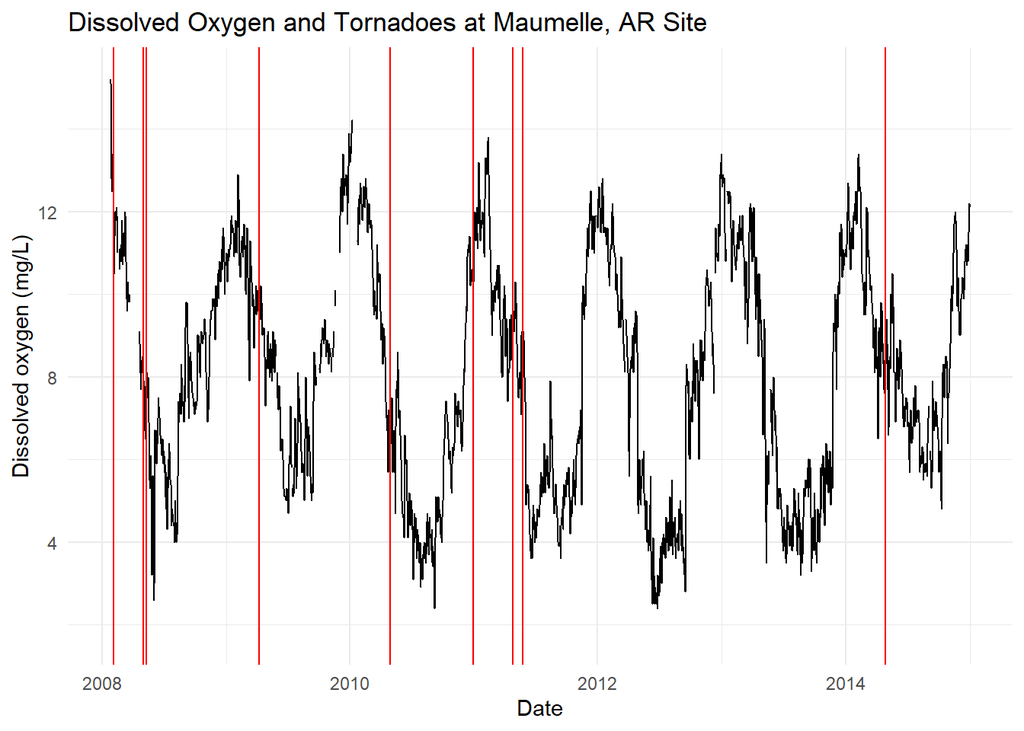

```r
mau_water_o2 + scale_x_date(limits = lubridate::as_date(c("2008-01-26", "2015-01-01")))
```

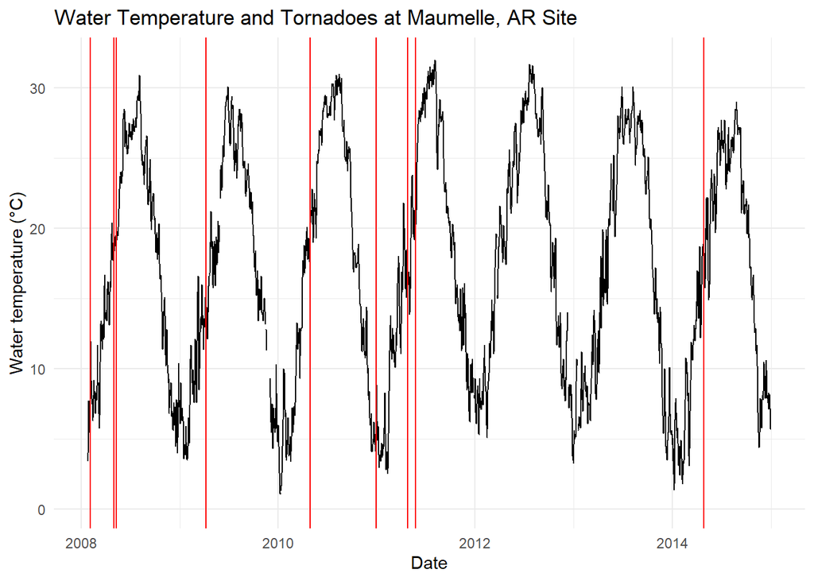

```r
ggsave("dissolved_o2.jpg")
mau_water_temp + scale_x_date(limits = lubridate::as_date(c("2008-01-26", "2015-01-01")))
```

```r
ggsave("water_temp.jpg")
```

## Citations

```r
citation("rnoaa")
```

```
##
##
##   Scott Chamberlain (2021). rnoaa: 'NOAA' Weather Data from R. R
##   package version 1.3.4. https://CRAN.R-project.org/package=rnoaa
##
## A BibTeX entry for LaTeX users is
##
##   @Manual{,
##     title = {rnoaa: 'NOAA' Weather Data from R},
##     author = {Scott Chamberlain},
##     year = {2021},
##     note = {R package version 1.3.4},
##     url = {https://CRAN.R-project.org/package=rnoaa},
##   }
```

```r
citation("dataRetrieval")
```

```
##
##
##   De Cicco, L.A., Hirsch, R.M., Lorenz, D., Watkins, W.D., 2021,
##   dataRetrieval: R packages for discovering and retrieving water data
##   available from Federal hydrologic web services, doi:10.5066/P9X4L3GE
##
## A BibTeX entry for LaTeX users is
##
##   @Manual{,
##     author = {Laura A. {De Cicco} and David Lorenz and Robert M. Hirsch and William Watkins and Mike Johnson},
##     title = {dataRetrieval: R packages for discovering and retrieving water data available from U.S. federal hydrologic web services},
##     publisher = {U.S. Geological Survey},
##     address = {Reston, VA},
##     version = {2.7.9},
##     institution = {U.S. Geological Survey},
##     year = {2021},
##     doi = {10.5066/P9X4L3GE},
##     url = {https://code.usgs.gov/water/dataRetrieval},
##   }
```